# 3.4 Practical: categorical predictor

Benjamin Rosenbaum

October 26, 2022

In this exercise, we will learn different ways to code a categorical predictor. We will also learn how to use the `generated quantities{}` block.

Suppose we have measurements of a continuous variable in 2 groups, e.g. individual body masses in 2 populations.

We want to test if both groups have a different mean.

statistical model:
$$\begin{aligned}
y_{1,i} & \sim \text{normal}(\mu_1, \sigma),\quad i=1,...,n_1 \\
y_{2,i} & \sim \text{normal}(\mu_2, \sigma),\quad i=1,...,n_2
\end{aligned}$$

Notice that here, we assume that both populations have the same standard deviation.

We could also model 2 separate standard deviations.

Research question: what is the mean difference $\delta=\mu_2-\mu_1$ of both populations?

# Setup

```r
rm(list=ls())
library(rstan)
library(coda)
library(BayesianTools)
library(brms)

setwd("~/Nextcloud/teaching Bayes 2021")

rstan_options(auto_write = TRUE)
options(mc.cores = 4) # number of CPU cores
```

# Generate data

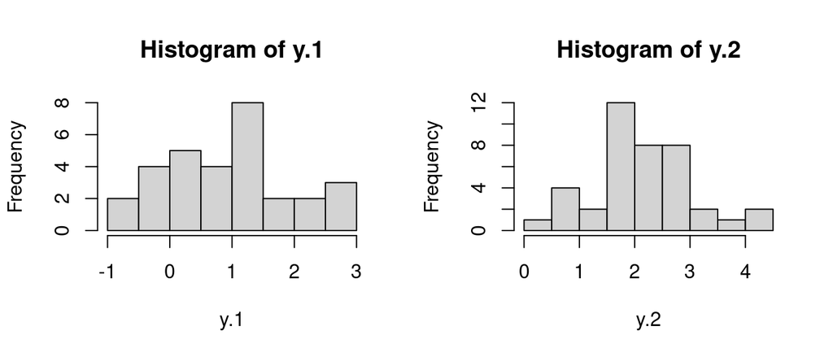

```r
set.seed(123) # initiate random number generator for reproducibility

n.1 = 30
mu.1 = 1
sigma.1 = 1

n.2 = 40
mu.2 = 2
sigma.2 = 1

y.1 = rnorm(n=n.1, mean=mu.1, sd=sigma.1)
y.2 = rnorm(n=n.2, mean=mu.2, sd=sigma.2)

par(mfrow=c(1,2))
hist(y.1)
hist(y.2)
```

# Stan code

We translate the statistical model above straightforward into a Stan model.

Diffence in means can be investigated after fitting. Alternatively, we can compute it in the model in the `generated quantities` block

```r
data = list(n1=n.1,
            n2=n.2,
            y1=y.1,
            y2=y.2)

stan_code = '
data {
  int n1;
  vector[n1] y1;
  int n2;
  vector[n2] y2;
}
parameters {
  real mu1;
  real mu2;
  real<lower=0> sigma;
}
model {
  // priors
  mu1 ~ normal(0, 10);
  mu2 ~ normal(0, 10);
  sigma ~ normal(0, 10);
  // likelihood
  y1 ~ normal(mu1, sigma);
  y2 ~ normal(mu2, sigma);
}
generated quantities{
  real delta;
  delta = mu2-mu1;
}
'
```

```r
stan_model = stan_model(model_code=stan_code)
fit.1  = sampling(stan_model, data=data)
```

```r
print(fit.1, digits=3, probs=c(0.025, 0.975))
```

```
## Inference for Stan model: 42ab72f5377cbb91167f2b62d07c706f.
## 4 chains, each with iter=2000; warmup=1000; thin=1;
## post-warmup draws per chain=1000, total post-warmup draws=4000.
##
##          mean se_mean    sd    2.5%   97.5% n_eff  Rhat
## mu1     0.955   0.003 0.171   0.624   1.287  3985 1.000
## mu2     2.166   0.003 0.150   1.864   2.470  3427 0.999
## sigma   0.924   0.001 0.081   0.781   1.097  3835 1.001
## delta   1.212   0.004 0.221   0.792   1.645  3737 1.000
## lp__  -28.919   0.028 1.274 -32.201 -27.474  2035 1.000
##
## Samples were drawn using NUTS(diag_e) at Thu Oct  7 15:06:29 2021.
## For each parameter, n_eff is a crude measure of effective sample size,
## and Rhat is the potential scale reduction factor on split chains (at
## convergence, Rhat=1).
```

Now we can check if `delta>0`

```
## ci_level: 0.8 (80% intervals)
```

```
## outer_level: 0.95 (95% intervals)
```

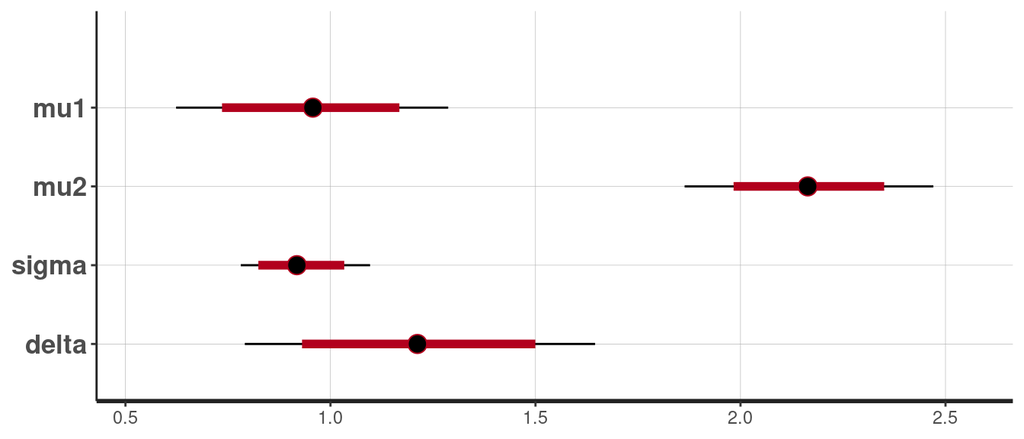

```r
plot(fit.1)
```

```r
posterior = as.matrix(fit.1)
head(posterior)
```

```
##           parameters
## iterations       mu1      mu2     sigma     delta      lp__
##       [1,] 0.9582488 2.178040 0.9952437 1.2197907 -28.00208
##       [2,] 0.9280431 2.160673 0.8245007 1.2326300 -27.95518
##       [3,] 0.8434813 1.891029 0.8071171 1.0475474 -30.83149
##       [4,] 0.9700242 1.879927 0.8988530 0.9099028 -29.36631
##       [5,] 1.1509269 2.440589 0.8962925 1.2896625 -30.00112
##       [6,] 1.1044751 2.328075 0.8563978 1.2235997 -28.75155
```

```r
sum(posterior[, "delta"]>0)/nrow(posterior)
```

```
## [1] 1
```